# Лабораторная работа № 9

Командная оболочка Midnight Commander

Чжан Вэньцзюнь

Российский университет дружбы народов

2026-10-20

# Информация

## Докладчик

- Чжан Вэньцзюнь
- зачётная книжка № 1132259051
- Российский университет дружбы народов им. П. Лумумбы

## Цель работы

- Освоение основных возможностей Midnight Commander
- Приобретение навыков просмотра каталогов и файлов
- Манипуляции с файлами и каталогами
- Работа со встроенным редактором

## Что такое Midnight Commander

- Псевдографическая командная оболочка для UNIX/Linux
- Две панели с содержимым каталогов
- Строка меню (`F9`), командная строка, подсказки `F1`–`F10`
- Работает в текстовом режиме, в том числе по SSH

## Функциональные клавиши

| Клавиша | Действие |
| --- | --- |
| `F1` | подсказка |
| `F3` | просмотр файла |
| `F4` | встроенный редактор |
| `F5` | копирование |
| `F6` | перенос/переименование |
| `F7` | создание каталога |
| `F8` | удаление |
| `F9` | меню mc |
| `F10` | выход |

# Выполнение работы

## Главный экран mc

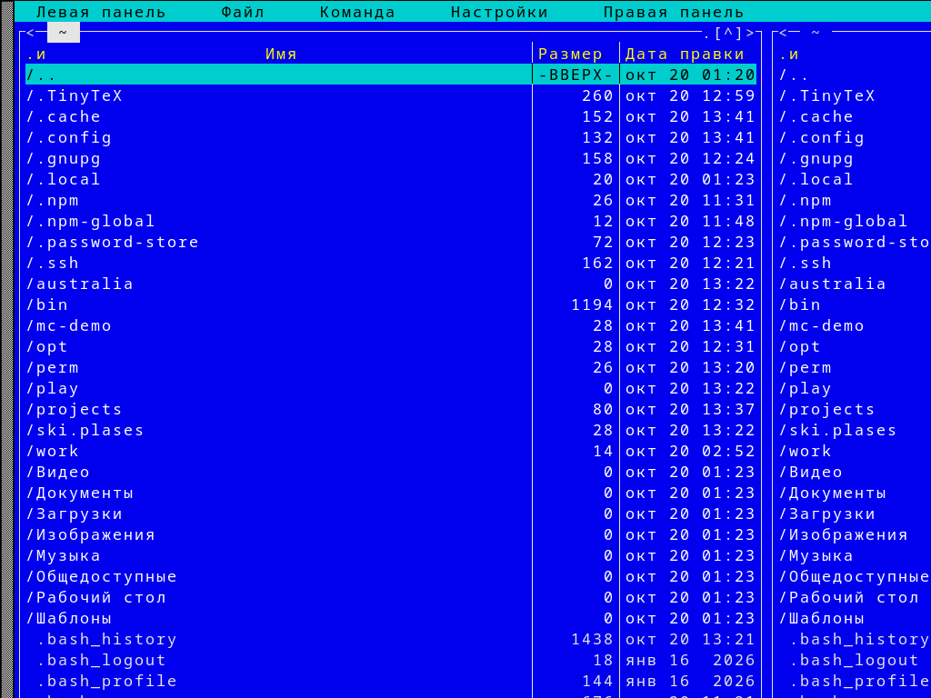

Главный экран Midnight Commander

- Сверху — меню: Левая панель, Файл, Команда, Настройки, Правая панель
- Две панели показывают содержимое каталогов
- Снизу — строка подсказок функциональных клавиш

## Операции с панелями

- `Insert` — выделить/снять выделение файла
- `+`, `-`, `*` — отметить группу, снять, обратить
- `Ctrl-u` — переставить панели
- `Ctrl-o` — отключить панели
- `Ctrl-x d` — сравнить каталоги
- Режимы панели: Информация, Дерево, Быстрый просмотр

## Меню «Файл»

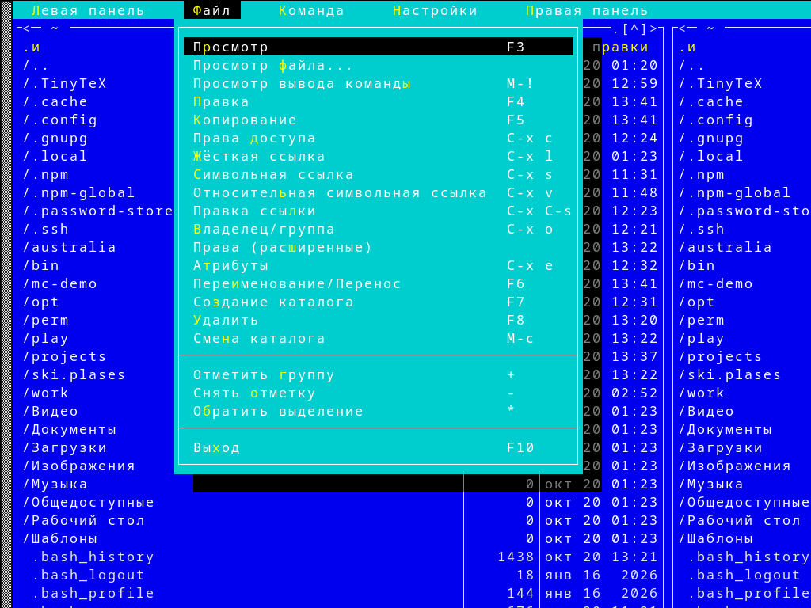

Подменю «Файл»

- Просмотр (`F3`), Правка (`F4`)
- Копирование (`F5`), Перенос (`F6`)
- Права доступа (`Ctrl-x c`), ссылки, владелец
- Создание каталога (`F7`), удаление (`F8`)

## Меню «Команда» и «Настройки»

**Команда:**

- Дерево каталогов, Поиск файла, Сравнить каталоги
- Размеры каталогов, История командной строки
- Редактирование файлов меню и расширений

**Настройки:**

- Конфигурация, Внешний вид, Настройки панелей
- Подтверждение, Распознание клавиш, Виртуальные ФС

## Встроенный редактор

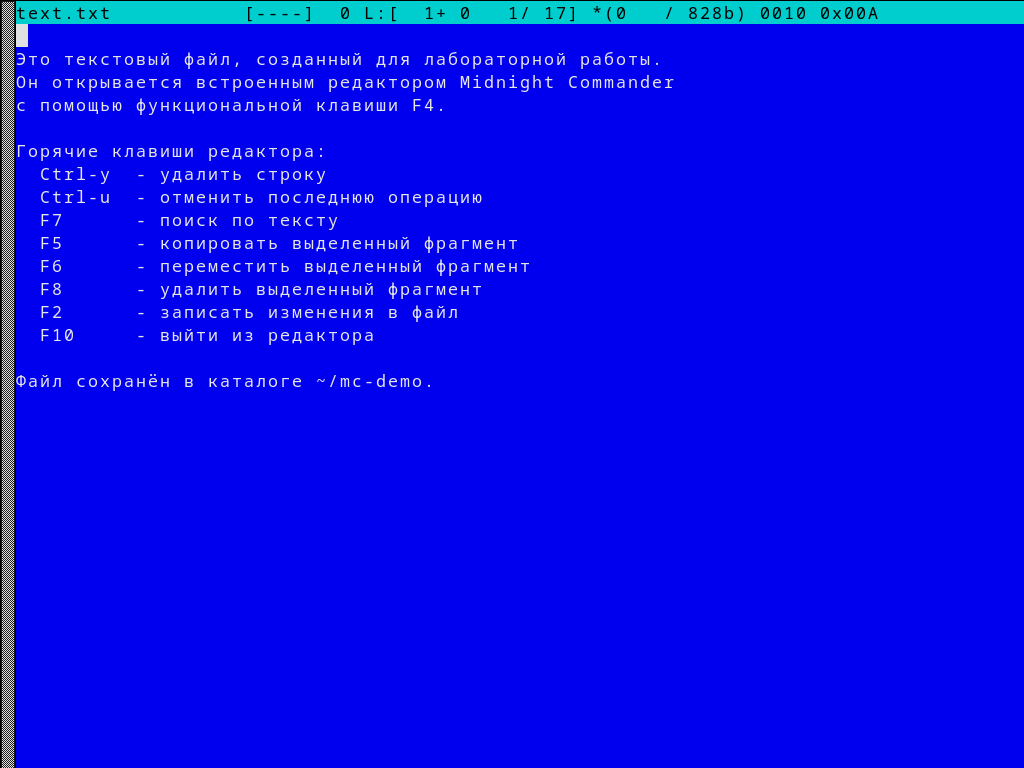

Встроенный редактор mc

- Вызов — `F4`
- `Ctrl-y` — удалить строку, `Ctrl-u` — отмена
- `F3` — выделение, `F5`/`F6` — копировать/перенести фрагмент
- `F7` — поиск, `F2` — сохранить, `F10` — выход

## Подсветка синтаксиса

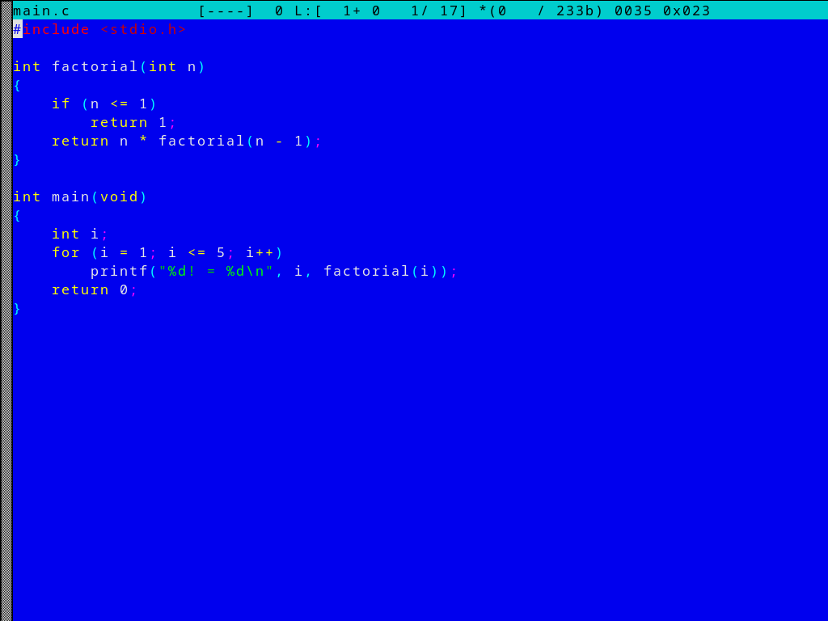

Подсветка синтаксиса языка C

- Включается и выключается через меню редактора
- Ключевые слова, строки, числа выделяются цветом
- Поддерживаются многие языки (C, Python, Bash и др.)

# Заключение

## Выводы

- Изучена структура экрана и меню Midnight Commander
- Освоены операции с панелями и режимы их отображения
- Изучены меню «Файл», «Команда», «Настройки»
- Освоен встроенный редактор и подсветка синтаксиса
- Приобретены навыки работы с файлами без команд shell

## Спасибо за внимание!

Вопросы?